# XBeach

## Introduction

XBeach is an open-source numerical model which is originally developed to simulate hydrodynamic and morphodynamic processes and impacts on sandy coasts with a domain size of kilometers and on the time scale of storms. Since then, the model has been applied to other types of coasts and purposes.

The model includes the hydrodynamic processes of short wave transformation (refraction, shoaling and breaking), long wave (infragravity wave) transformation (generation, propagation and dissipation), wave-induced setup and unsteady currents, as well as overwash and inundation. The morphodynamic processes include bed load and suspended sediment transport, dune face avalanching, bed update and breaching. Effects of vegetation and of hard structures have been included. The model has been validated with a series of analytical, laboratory and field test cases using a standard set of parameter settings.

## Hydrodynamics options

XBeach was originally developed as a short-wave averaged but wave-group resolving model, allowing resolving the short wave variations on the wave group scale and the long waves associated with them. Since the original paper by `Roelvink2009` a number of additional model options have been implemented, thereby allowing users to choose which time-scales to resolve:

- Stationary wave model (keyword: `wavemodel` = *stationary*), efficiently solving wave-averaged equations but neglecting infragravity waves;
- Surfbeat mode (instationary) (keyword: `wavemodel` = *surfbeat*), where the short wave variations on the wave group scale (short wave envelope) and the long waves associated with them are resolved;
- Non-hydrostatic mode (wave-resolving) (keyword: `wavemodel` = *nonh*), where a combination of the non-linear shallow water equations with a pressure correction term is applied, allowing to model the propagation and decay of individual waves.

### Short wave action balance

The wave forcing in the shallow water momentum equation is obtained from a time dependent version of the wave action balance equation. Similar to Delft University (stationary) HISWA model (`Holthuijsen1989`) the directional distribution of the action density is taken into account, whereas the frequency spectrum is represented by a frequency, best represented by the spectral parameter ${f}_{m-1,0}$ . The wave action balance is then given by:

\begin{array}{l} \frac{\partial A}{\partial t} +\frac{\partial c_{x} A}{\partial x} +\frac{\partial c_{y} A}{\partial y} +\frac{\partial c_{\theta } A}{\partial \theta } =-\frac{D_{w} +D_{f} +D_{v} }{\sigma } \end{array}

In which the wave action $A$ is calculated as:

\begin{array}{l} A(x,y,t,\theta )=\frac{S_{w} (x,y,t,\theta )}{\sigma (x,y,t)} \end{array}

where $\theta$ represents the angle of incidence with respect to the x-axis, ${S}_{w}$ represents the wave energy density in each directional bin and $\sigma$ the intrinsic wave frequency. The intrinsic frequency $\sigma$ and group velocity ${c}_{g}$ is obtained from the linear dispersion relation. The intrinsic frequency is for example obtained with:

\begin{array}{l} \sigma =\sqrt{gk\tanh kh} \end{array}

The wave action propagation speeds in $x$, $y$ and directional space are given by:

\begin{array}{l} {c_{x} (x,y,t,\theta )=c_{g} \cos (\theta )} \\ {c_{y} (x,y,t,\theta )=c_{g} \sin (\theta )} \\ {c_{\theta } (x,y,t,\theta )=\frac{\sigma }{\sinh 2kh} \left(\frac{\partial h}{\partial x} \sin \theta -\frac{\partial h}{\partial y} \cos \theta \right)} \end{array}

where $h$ represents the local water depth and $k$ the wave number. The intrinsic wave frequency $\sigma$ is determined without wave current interaction, which means it is equal to the absolute radial frequency $\omega$.

\begin{array}{c} {\frac{\partial u^{L} }{\partial t} +u^{L} \frac{\partial u^{L} }{\partial x} +v^{L} \frac{\partial u^{L} }{\partial y} -f\, v^{L} \, -\, \nu _{h} \left(\frac{\partial ^{2} u^{L} }{\partial x^{2} } +\frac{\partial ^{2} u^{L} }{\partial y^{2} } \right)=\frac{\tau _{sx} }{\rho h} -\frac{\tau _{bx}^{E} }{\rho h} -g\frac{\partial \eta }{\partial x} +\frac{F_{x} }{\rho h} +\frac{F_{v,x} }{\rho h} } \\ {\frac{\partial v^{L} }{\partial t} +u^{L} \frac{\partial v^{L} }{\partial x} +v^{L} \frac{\partial v^{L} }{\partial y} +f\, u^{L} \, -\, \nu _{h} \left(\frac{\partial ^{2} v^{L} }{\partial x^{2} } +\frac{\partial ^{2} v^{L} }{\partial y^{2} } \right)=\frac{\tau _{sy} }{\rho h} -\frac{\tau _{by}^{E} }{\rho h} -g\frac{\partial \eta }{\partial y} +\frac{F_{y} }{\rho h} +\frac{F_{v,y} }{\rho h} } \\ {\frac{\partial \eta }{\partial t} +\frac{\partial hu^{L} }{\partial x} +\frac{\partial hv^{L} }{\partial y} =0} \end{array}

#### Spectral conditions

The most-used wave boundary condition in XBeach is a spectral type. The input description of spectral wave boundary conditions can be found in :ref:`sec-spectral-wbc`. XBeach allows the user to define these with three possibilities:

1. : With this option you define the boundary condition as parametric spectral input. The parameters (i.e. the spectral shape, the wave period and the directional spreading) can be specified. The option is especially handy when there is no nested model or measured spectrum. Here are two options:

   a. Specify a single parametric spectrum (`wbctype` = *jons*).

   b. Specify a series of parametric spectra (`wbctype` = jons_table).
2. : In this case the two-dimensional (frequency-direction) output by the spectral wave model SWAN (.sp2 files) can be specified. (keyword :par:`wbctype` = *swan*). This option is especially convenient when nesting XBeach into a SWAN model.
3. : In this case a more general type spectrum can be specified. (`wbctype` = *vardens*). This option is often used when a measured spectrum is available.

#### Non-spectral conditions

XBeach also allows the user to define non-spectral wave boundary conditions. This is a variation of both wave conditions without wave groups and time series. The input description of non-spectral wave boundary conditions can be found in :ref:`sec-non-spectral-wbc`. XBeach allows the user to define these with two possibilities:

   a. Specify a single sea state (`wbctype` = *stat*)

   a. First-order time series of waves (`wbctype` = *ts_1*). XBeach will calculate the bound long wave based on the theory of `LonguetHiggins1964`).

   b. Second-order time series of waves (`wbctype` = *ts_2*). The bound long wave is specified by the user via a long wave elevation.

   c. It is also possible to specify a variation in time of the horizontal velocity, vertical velocity and the free surface elevation (`wbctype` = *ts_nonh*). Last two terms are optional in this boundary conditions type.

```python
import sys;sys.path.append('../xbeach/')
from importlib import reload
from libs import *
```

### Parameters

```python
with open(str(root / 'parameters' / 'params.txt'), 'r') as fin:
    lines = fin.readlines()
    for line in lines:
        print(line.strip())
```

```
%%%%%%%%%%%%%%%%%%%%%%%%%%%%%%%%%%%%%%%%%%%%%%%%%%%%%%%%%%%%%%%%%%%%%%%%%%%%%%%%
%%% XBeach parameter settings input file                                     %%%
%%%                                                                          %%%
%%% date:     09-Mar-2019 17:41:41                                           %%%
%%% function: xb_write_params                                                %%%
%%%%%%%%%%%%%%%%%%%%%%%%%%%%%%%%%%%%%%%%%%%%%%%%%%%%%%%%%%%%%%%%%%%%%%%%%%%%%%%%

%%% Flow boundary condition parameters %%%%%%%%%%%%%%%%%%%%%%%%%%%%%%%%%%%%%%%%%

front        = abs_2d
left         = neumann
right        = neumann
back         = abs_2d
epsi         = -1

%%% Flow parameters %%%%%%%%%%%%%%%%%%%%%%%%%%%%%%%%%%%%%%%%%%%%%%%%%%%%%%%%%%%%

bedfriction  = manning

%%% General %%%%%%%%%%%%%%%%%%%%%%%%%%%%%%%%%%%%%%%%%%%%%%%%%%%%%%%%%%%%%%%%%%%%

avalanching  = 0
dtheta_s     = 5
single_dir   = 0
vegetation    = 1
veggiefile    = vegetation.txt
veggiemapfile = temp.txt

%%% Grid parameters %%%%%%%%%%%%%%%%%%%%%%%%%%%%%%%%%%%%%%%%%%%%%%%%%%%%%%%%%%%%

gridform     = delft3d
xyfile       = med_res.grd
depfile      = med_res.dep
posdwn       = -1
nx           = 325
ny           = 325
alfa         = 0
vardx        = 1
xori         = 0
yori         = 0
```

[output cut: 51 more lines]

```
nglobalvar   = 6
zb
zs
H
u
v
sigm

nmeanvar     = 6
zb
zs
H
u
v
sigm
```

## Grid set-up

The grid applied is a staggered grid, where the bed levels, water levels, water depths and concentrations are defined in cell centers, and velocities and sediment transports are defined in u- and v-points, viz. at the cell interfaces. In the wave energy balance, the energy, roller energy and radiation stress are defined at the cell centers, whereas the radiation stress gradients are defined at u- and v-points.

Velocities at the u- and v-points are denoted by the output variables uu and vv respectively; velocities u and v at the cell centers are obtained by interpolation and are for output purpose only. The water level, zs, and the bed level, zb, are both defined positive upward. uv and vu are the u-velocity at the v-grid point and the v-velocity at the u-grid point respectively. These are obtained by interpolation of the values of the velocities at the four surrounding grid points.

The model solves coupled 2D horizontal equations for wave propagation, flow, sediment transport and bottom changes, for varying (spectral) wave and flow boundary conditions.

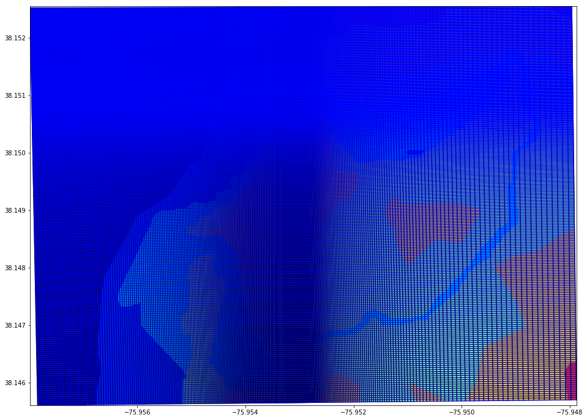

```python
fig,ax = plt.subplots(figsize=(16,12))
ax.plot(x,y,'k')
ax.plot(x.transpose(),y.transpose(),'b')
ax.contourf(x,y,z[0,:,:],cmap='jet',vmin=-1.5,vmax=2)
ax.set_xlim([x.min(),x.max()])
ax.set_ylim([y.min(),y.max()])
plt.show()
```

## Vegetation

The presence of aquatic vegetation within the area of wave propagation or wave breaking results in an additional dissipation mechanism for short waves. This is modeled using the approach of `Mendez2004a`, which was adjusted by `Suzuki2012` to take into account vertically heterogeneous vegetation, see `VanRooijen2015`. The short wave dissipation due to vegetation is calculated as function of the local wave height and several vegetation parameters. The vegetation can be schematized in a number of vertical elements with each specific property. In this way the wave damping effect of vegetation such as mangrove trees, with a relatively dense root system but sparse stem area, can be modeled. The dissipation term is then computed as the sum of the dissipation per vegetation layer (`Suzuki2012`):

\begin{array}D_{v} =\sum _{i=1}^{n_{v} }D_{v,i} \end{array}

where ${D}_{v,i}$ is the dissipation by vegetation in vegetation layer $i$ and ${n}_{v}$ is the number of vegetation layers. The dissipation per layer is given by:

\begin{array}{l} {D_{v,i} =A_{v} \cdot \frac{\rho \widetilde{C}_{D,i} b_{v,i} N_{v,i} }{2\sqrt{\pi } } \left(\frac{kg}{2\sigma } \right)^{3} H_{rms} ^{3} ,{\; with}} \\ {A_{v} =\frac{\left(\sinh ^{3} k\alpha _{i} h-\sinh ^{3} k\alpha _{i-1} h\right)+3\left(\sinh k\alpha _{i} h-\sinh k\alpha _{i-1} h\right)}{3k\cosh ^{3} kh} } \end{array}

where $\widetilde{C}_{D,i}$ is a (bulk) drag coefficient, ${b}_{v,i}$ is the vegetation stem diameter, ${N}_{v,i}$ is the vegetation density, and $\alpha_{i}$ is the relative vegetation height (= ${h}_{v} / h$) for layer $i$. In case only one vegetation layer is specified, the plants are assumed to be vertically uniform, which would for example typically apply in case of modeling sea grass.

### Damping by vegetation

The presence of aquatic vegetation within the area of wave propagation or wave breaking may not only result in short wave dissipation (`sec-dissipation`), but also in damping of infragravity waves and/or mean flow. Since both long waves and mean flow are fully resolved with the nonlinear shallow water equations, the effect of vegetation can be modeled using a drag force (e.g. `Dalrymple1984`), which can be directly added to the momentum equations (`VanRooijen2015`, equation `glm-momentum`):

\begin{array}{l} F_{v} =F_{D} =\frac{1}{2} \rho C_{D} b_{v} Nu\left|u\right| \end{array}

Where ${C}_{D}$ is a drag coefficient, ${b}_{v}$ is the vegetation stem diameter, `N` is the vegetation density and `u` is the wave or current related velocity. To take into account the velocity due to mean flow and infragravity waves, we use the Lagrangian velocity (${u}^{L}$) here. The vegetation-induced time varying drag force is then calculated as the sum of the vegetation-induced drag force per vegetation layer:

\begin{array}{l} {F_{v} (t)=\sum _{i=1}^{n_{v} }F_{v,i} (t)} \\ {F_{v,i} (t)=\frac{1}{2} \rho \widetilde{C}_{D,i} b_{v,i} N_{v,i} h_{v,i} u^{L} (t)\left|u^{L} (t)\right|} \end{array}

where $\widetilde{C}_{D,i}$ is a (bulk) drag coefficient, ${b}_{v,i}$ is the vegetation stem diameter, ${n}_{v,i}$ is the vegetation density, and ${h}_{v,i}$ is the vegetation height for layer $i$.

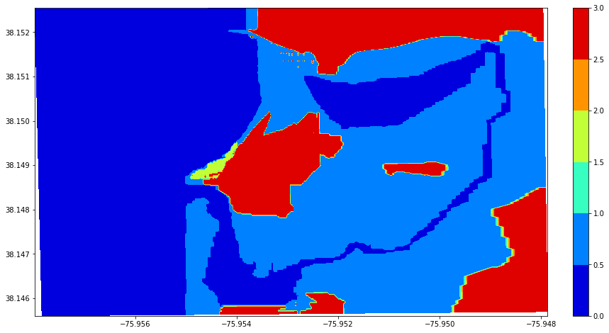

```python
fig,ax = plt.subplots(figsize=(16,8))
levels = np.arange(0,3.1,.5)
plt.contourf(x,y,vege[:,:],cmap='jet',vmin=0,vmax=np.max(levels),levels=levels)
plt.colorbar(cmap='jet',pad=0.04)
ax.set_xlim([x.min(),x.max()])
ax.set_ylim([y.min(),y.max()])
plt.show()
```

## Bottom friction

The short wave dissipation by bottom friction is modeled as

###### sw-bottom-friction

\begin{array}{c} D_{f} =\frac{2}{3\pi } \rho f_{w} \left(\frac{\pi H_{rms} }{T_{m01} \sinh kh} \right)^{3} \end{array}

In `sw-bottom-friction` the ${f}_{w}$ is the short-wave friction coefficient. This value only affects the wave action equation and is unrelated to bed friction in the flow equation. Studies conducted on reefs (e.g.`Lowe2007`) indicate that${f}_{w}$ should be an order of magnitude (or more) larger than the friction coefficient for flow (${c}_{f}$) due to the dependency of wave frictional dissipation rates on the frequency of the motion.

The derivation of the short wave dissipation term is based time-averaged instantaneous bottom dissipation using the Johnson friction factor ${f}_{w}$ of the bed shear stress:

###### sw-bottom-friction-0

\begin{array}{c}{D}_{f} =\left|\tau u\right|=\frac{1}{2} \rho f_{w} \left|\tilde{u}\right|^{3} \end{array}

###### orbital-velocity

\begin{array}{c}u_{orb} =\frac{\pi H_{rms} }{T_{p} \sinh (kh)} \end{array}

If we consider the slowly-varying dissipation in wave groups, we need only to average over a single wave period and we can use a monochromatic (regular wave) expression. If we want to have the time-average dissipation over a full spectrum we get the best approximation from considering a linear Gaussian distribution.`Guza1985` give pragmatic expressions for both cases.

For the monochromatic case:

\begin{array}{c}\left\langle \left|\tilde{u}\right|^{3} \right\rangle =1.20\left\langle \left|\tilde{u}\right|^{2} \right\rangle ^{3/2} =1.20\left(\frac{1}{2} u_{orb}^{2} \right)^{3/2} =0.42u_{orb}^{3} \end{array}

For the linear Gaussian approximation:

\begin{array}{c} \left\langle \left|\tilde{u}\right|^{3} \right\rangle =1.60\left\langle \left|\tilde{u}\right|^{2} \right\rangle ^{3/2} =1.60\left(\frac{1}{2} u_{orb}^{2} \right)^{3/2} =0.57u_{orb}^{3}\end{array}

Combining `sw-bottom-friction-0` and `orbital-velocity-monochromatic` we get:

\begin{array}{c} \left\langle \tilde{D}_{f} \right\rangle =0.21\rho f_{w} u_{orb}^{3}\end{array}

In XBeach the orbital velocity amplitude is computed as in `orbital-velocity-monochromatic` and the dissipation according to `sw-bottom-friction-instationary`, which is correct for the case of instationary simulations on wave-group scale.

For the stationary case formulations :`sw-bottom-friction-0` and `orbital-velocity-gaussian` are similarly combined into:

\begin{array}{c} \left\langle \tilde{D}_{f} \right\rangle =0.28\rho f_{w} u_{orb}^{3} \end{array}

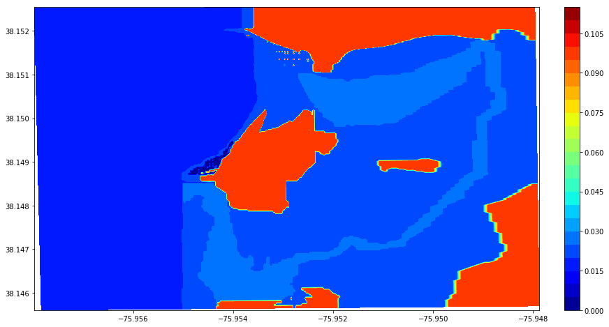

```python
fig,ax = plt.subplots(figsize=(16,8))
levels = np.arange(0,0.12,0.005)
plt.contourf(x,y,bed,cmap='jet',vmin=0, vmax=np.max(levels),levels=levels)
plt.colorbar(cmap='jet',pad=0.04)
ax.set_xlim([x.min(),x.max()])
ax.set_ylim([y.min(),y.max()])
plt.show()
```

#### Create 2d contour map

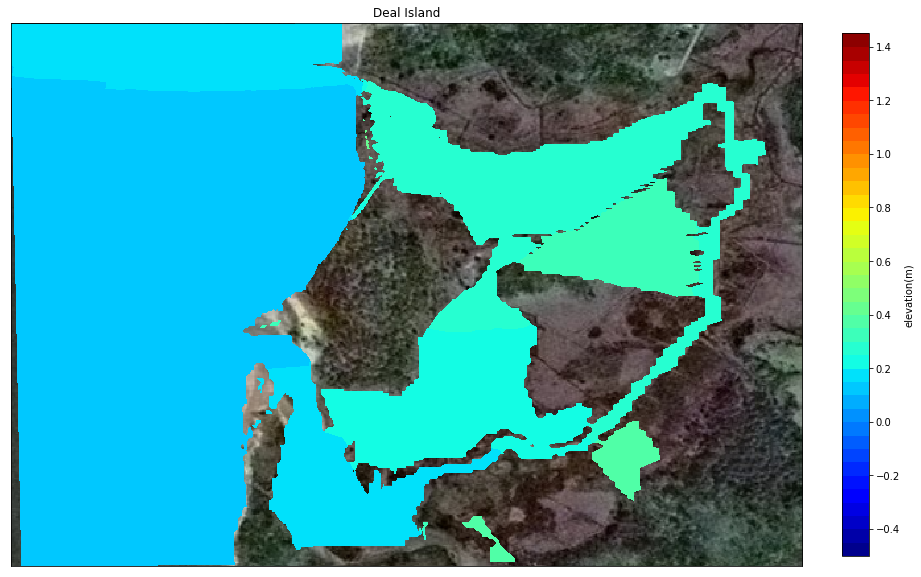

```python
lat1,lat2 = np.min(y),np.max(y)
lon1,lon2 = np.min(x),np.max(x)
title = 'Deal Island'
levels = np.arange(-0.5,1.5,0.05)
xbeach.contour_map(x,y,z[0,:,:],zs[17,:,:],title,levels,lat1,lat2,lon1,lon2)
```

#### Find Observation Stations

```python
station_x = [-75.953653,-75.953486,-75.953338,-75.952953] # s1,s2,s3,s4
station_y = [38.151136,38.151207,38.151208,38.151215]
gridx,gridy = [], []
for i in range(0,4):
    node = xbeach.find_node_ak(x,y,station_y[i],station_x[i])
    gridx.append(node[0])
    gridy.append(node[1])
```

#### Generate Model stations

```python
water = xbeach.correct_hobo(str(hobos / 't1.mat'))
time = pd.date_range(start=pd.to_datetime('2018-09-12 19'),periods=int(len(zs[:,gridx[0],gridy[0]])),freq='20min')
model = pd.DataFrame({'date time':time,'s1':zs[:,gridx[0],gridy[0]],'s2':zs[:,gridx[1],gridy[1]],
                      's3':zs[:,gridx[2],gridy[2]],'s4':zs[:,gridx[3],gridy[3]]})
```

#### Generate Cross-section

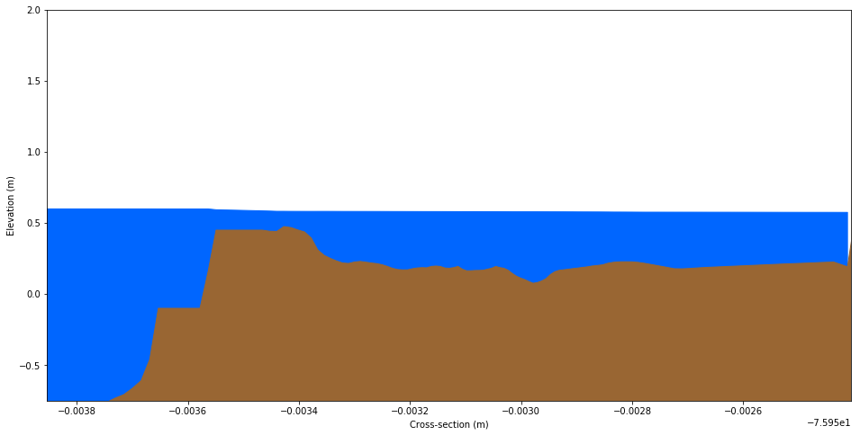

```python
fig,ax = plt.subplots(figsize=(16,8))
ax.fill_between(x[gridx[0],:],zs[25,gridx[0],:],-3,color='#0066ff')
ax.fill_between(x[gridx[0],:],z[25,gridx[0],:],-3,color='#996633')
ax.set_xlabel('Cross-section (m)')
ax.set_ylabel('Elevation (m)')
ax.set_xlim([x[gridx[0],gridy[0]]-0.0002,x[gridx[3],gridy[3]]+0.00055])
ax.set_ylim([-0.75,2])
plt.show()
```

#### Generate 2d contour video with observation stations

```python
lat1,lat2 = np.min(y),np.max(y)
lon1,lon2 = np.min(x),np.max(x)
title = 'Deal Island'
levels = np.arange(-0.3,2,0.1)
start,time = '2018091219', 280
title = 'Deal Island '
xbeach.contour_stations(x,y,zs,water,gridx,gridy,model,start,time,title,levels,lat1,lat2,lon1,lon2)
```

[figure not shown]

#### Generate 3d video

```python
title = 'Deal Island'
levels = np.arange(-0.3,1.50001,0.1)
start,time = '2018091219',60
title = 'Deal Island '
xbeach.video_3d(x,y,z,h+zs,start,time,title,levels)
```

[figure not shown]

#### Generate Contour video with velocity vectors

```python
lat1,lat2 = np.min(y),np.max(y)
lon1,lon2 = np.min(x),np.max(x)
title = 'Deal Island'
levels = np.arange(-0.3,1.5,0.1)
start,time = '2018091219',60
xbeach.map_velocity(x,y,zs,u,v,start,time,title,levels,lat1,lat2,lon1,lon2,gridspace=75)
```

[figure not shown]

#### Max velocity in the model

```python
np.max(np.sqrt(np.square(u)+np.square(v)))
```

```
0.6554845707896482
```

# Other Parameters to explore

## Non-hydrostatic pressure correction

\begin{array}{c} \frac{\delta w}{\delta t} +\frac{\delta q}{\delta z} =0 \end{array}

In $w$ is the vertical velocity and $z$ is the vertical coordinate. The vertical velocity at the bed is set by the kinematic boundary condition:

\begin{array}{c} w_{b} =u\frac{\delta (\eta -h)}{\delta x} \end{array}

Combining the Keller-box method (`Lam1976`), as applied by `Stelling2003b` for the description of the pressure gradient in the vertical, the dynamic pressure at the bed can be described by:

\begin{array}{c} q_{b} =-\frac{h}{2} \left(\left. \frac{\delta q}{\delta z} \right|_{s} +\left. \frac{\delta q}{\delta z} \right|_{b} \right) \end{array}

Substituting in allows the vertical momentum balance at the surface to be described by:

\begin{array}{c} \frac{\delta w_{s} }{\delta t} =2\frac{q_{b} }{h} -\frac{\delta w_{b} }{\delta t} \end{array}

In the subscript $s$ refers to the location at the surface. The dynamic pressure at the bed is subsequently solved by combining and the local continuity equation:

\begin{array}{c} \frac{\delta u}{\delta x} +\frac{w_{s} -w_{b} }{h} =0 \end{array}

In order to improve the computed location and magnitude of wave breaking, the hydrostatic front approximation (HFA) of `Smit2014` is applied, in which the pressure distribution under breaking bores is assumed to be hydrostatic. Following the recommendations of `Smit2014`, we consider hydrostatic bores if $\frac{\delta \eta }{\delta t} >0.6$ and reform if $\frac{\delta \eta }{\delta t} <0.3$. The values can respectively be changed with the keywords `maxbrsteep` and `secbrsteep`.

Although this method greatly oversimplifies the complex hydrodynamics of plunging waves, `McCall2014` shows that the application of this method provides sufficient skill to describe dominant characteristics of the flow, without requiring computationally expensive high-resolution discretization of the vertical and surface tracking of overturning waves.

## Reduced two layer model (nh+)

The reduced two layer model was implemented to improve the dispersive behaviour of the non-hydrostatic model (keyword: `nhq3d`). Due to the additional layer, frequency dispersion is more accurately modelled than with the depth-averaged formulation. Mostly, the addition of an extra layer will increase the computational time significantly, but a simplified (reduced) lower layer is applied to reduce the extra computational effort. It is assumed that the non-hydrostatic pressure is constant in the lower layer. This means that the non-hydrostatic pressure at the bottom has the same value as the non-hydrostatic pressure between the layers. Still the non-hydrostatic pressure at the surface is zero, which means that for every location in the domain there is one non-hydrostatic unknown.

Then, the momentum equations for $U$, $\Delta u$ and $w_2$ are given by,

\begin{array}{c} \frac{\partial (h U)}{\partial t} + g h\frac{\partial \xi}{\partial x} + \frac{\partial}{\partial x}\left(hU^2\right) + \frac{\partial}{\partial x} \left(\frac{1+\alpha}{2}hq\right) - q \frac{\partial d}{\partial x} = \tau_0 \end{array}

\begin{array}{c} \frac{\partial h \Delta u}{\partial t} + \frac{\partial h\Delta u U}{\partial x} + \frac{\partial}{\partial x}\left(\frac{hq}{2}\right) + \frac{hq}{2-2\alpha}\frac{\partial \alpha}{\partial x} - \frac{q}{1-1\alpha}\frac{\partial \xi}{\partial x} = - \frac{\tau_{0}}{\alpha} + \frac{\tau_{1}}{\alpha(1-\alpha)} \end{array}

\begin{array}{c} \frac{\partial h w_2}{\partial t} + \frac{\partial}{\partial x} \left(hU w_2 \right) - \frac{ q}{(1-\alpha)} = 0 \end{array}

Due to the simplified non-hydrostatic pressure in the lower layer, the vertical velocity between the layers is neglected. Thus, only the continuity relation for the upper layer is required. This relation in terms of the reduced two layer formulation is given as,

\begin{array}{c} \frac{\partial}{\partial x} \left[(1+\alpha)hU + (1-\alpha)h\alpha\Delta u\right] + 2 w_2-\bar{u}_2\frac{\partial \xi}{\partial x} - \bar{u}_1\frac{\partial z_1}{\partial x} = 0 \end{array}

To determine the water elevation, the global continuity equation is applied,

\begin{array}{c} \frac{\partial \xi}{\partial t} + \frac{\partial hU}{\partial x} = 0 \end{array}

These equatuons are used to solve $U$, $\Delta u$, $w_2$ and $\xi$

When using the reduced two layer model, the model is forced with both $U$ and $\Delta u$. Linear wave theory is used to generate the layer-averaged velocities, which can be transformed to $U$ and $\Delta u$ by applying equation `layer_transformation`.

# Wave shape

The morphodynamic model considered is (short) wave averaged and resolves hydrodynamics associated with the wave group time scale. As a result the short wave shape is not solved for. However, as waves propagate from deep water onto beaches, their surface form and orbital water motion become increasingly non-linear because of the amplification of the higher harmonics.

There are two wave forms implemented to take this non-linearity into account:

- A formulation of `Ruessink2012` based on a parameterization with the Ursell number. (keyword: `waveform` = *ruessink_vanrijn*)
- A formulation of `VanThieldeVries2009a` based on the parameterized wave shape model of `Rienecker1981` (keyword: `waveform` = vanthiel)

\begin{array} U_{r} =\frac{3}{4} \frac{0.5H_{s} k}{(kh)^{3} }\end{array}

The value for the skewness and asymmetry is calculated with the use of a Boltzmann sigmoid. The skewness and asymmetry are a function of $\Psi$. In the formulation of `Ruessink2012` the ${p}_{1:6}$ are used as parameterized factors on the data set of field observations.

\begin{array}{c} {B=p_{1} +\frac{p_{2} -p_{1} }{1+\exp \frac{p_{3} -\log Ur}{p_{4} } } } \\ {\psi =-90+90\tanh (p_{5} /Ur^{p_{6} } )} \\ {} \\ {S_{k} =B\cos \psi {\; \; \; and\; \; \; }A_{s} =B\sin \psi } \end{array}

# Dissipation

In XBeach there are three short wave dissipation processes that can be accounted for: wave breaking (${D}_{w}$), bottom friction (${D}_{f}$) and vegetation (${D}_{v}$). The three processes are explained in more detail in the following subsections.

#### Wave breaking

Five different wave breaking formulations are implemented in XBeach. The formulations can be selected using the keyword `break`.

##### Different wave breaking formulations implemented

| Wave breaking formula | Type of waves | keyword |
| --- | --- | --- |
| Roelvink (1993a) | Instationary | roelvink1 |
| Roelvink (1993a) extended | Instationary | roelvink2 |
| Daly et al. (2010) | Instationary | roelvink_daly |
| Baldock et al. (1998) | Stationary | baldock |
| Janssen & Battjes (2007) | Stationary | janssen |

For the surf beat approach the total wave energy dissipation, i.e. directionally integrated, due to wave breaking can be modeled according to `Roelvink1993a` (`break` = *roelvink1*). In the formulation of the dissipation due to wave breaking the idea is to calculate the dissipation with a fraction of breaking waves (${Q}_{b}$) multiplied by the dissipation per breaking event. In this formulation $\alpha$ is applied as wave dissipation coefficient of O (keyword:`alpha`), ${T}_{rep}$ is the representative wave period and ${E}_{w}$ is the energy of the wave. The fraction of wave breaking is determined with the root-mean-square wave height (${H}_{rms}$) and the maximum wave height (${H}_{max}$). The maximum wave height is calculated as ratio of the water depth ($h$) plus a fraction of the wave height ($\delta H_{rms}$, keyword:`delta`) using a breaker index $\gamma$ (keyword:`gamma`). In the formulation for ${H}_{rms}$ the $\rho$ represents the water density and $g$ the gravitational constant. The total wave energy ${E}_{w}$ is calculated by integrating over the wave directional bins.

wave-breaking-roelvink1 \begin{array}{c} {\bar{D}_{w} =2\frac{\alpha }{T_{rep} } Q_{b} E_{w} {\; }} \\ {Q_{b} {=1-exp}\left(-\left(\frac{H_{rms} }{H_{\max } } \right)^{n} \right),\quad H_{rms} =\sqrt{\frac{8E_{w} }{\rho g} } ,\quad H_{\max } =\gamma \cdot (h+\delta H_{rms} )} \\ {E_{w} (x,y,t)=\int _{0}^{2\pi }S_{w} (x,y,t,\theta )d\theta } \end{array}

# Runup

\begin{array}{c} \frac{{R}_{max}}{{H}_{0}} =\xi_{0} \end{array}

where $\alpha$ is the beach slope angle, $R_{max}$ is the maximum vertical run up, $H_{0}$ equals the depp-water significant wave height, and $\xi_{0}$ is the Iribarren number.

\begin{array}{c} \xi_{0} = \frac{\tan{\alpha}}{\sqrt{\frac{H}{L_{0}}}} \end{array}

$\frac{H}{L_{0}}$ = wave steepness

$\alpha$ = slope angle